# Working with point data - Part 1

### Introduction

We now have all of our data prepared for harp and we aer ready to work with. That work includes undertsanding how harp data are structured, how to plot forecast data, how to manipulate the data, and verification.

We’ll be making use of all of the harp packages in this section, so we can just attach the full set of harp packages (and as always tidyverse and here)

```r
library(harp)
library(tidyverse)
library(here)
```

### Deterministic data

Let’s start with our deterministic data from the AROME Arctic model and member 0 of MEPS. First we load the data into our environment with the function `read_point_forecast`. As with other functions, we need to tell the function the start and end dates that we want, the names of the models, the parameter, the frequency of the forecasts, the path to the data and whether it is deterministic or ensemble data.

```r
s10m <- read_point_forecast(
  start_date = 2019021700,
  end_date   = 2019021718,
  fcst_model = c("AROME_Arctic_prod", "MEPS_prod"),
  fcst_type  = "det",
  parameter  = "S10m",
  by         = "6h",
  file_path  = here("data/FCTABLE/deterministic")
)
s10m
## ● AROME_Arctic_prod
## # A tibble: 17,612 x 10
##    fcdate fcst_cycle leadtime model_elevation     p parameter   SID units
##     <int> <chr>         <int>           <dbl> <dbl> <chr>     <int> <chr>
##  1 1.55e9 00                0            63.9    NA S10m       1001 m/s
##  2 1.55e9 00                0             1.4    NA S10m       1002 m/s
##  3 1.55e9 00                0            24.9    NA S10m       1003 m/s
##  4 1.55e9 00                0           162.     NA S10m       1004 m/s
##  5 1.55e9 00                0            -2.7    NA S10m       1006 m/s
##  6 1.55e9 00                0            21.6    NA S10m       1007 m/s
##  7 1.55e9 00                0            67.2    NA S10m       1008 m/s
##  8 1.55e9 00                0             1.2    NA S10m       1009 m/s
##  9 1.55e9 00                0             3.3    NA S10m       1010 m/s
## 10 1.55e9 00                0            20.7    NA S10m       1011 m/s
## # … with 17,602 more rows, and 2 more variables: validdate <int>,
## #   AROME_Arctic_prod_det <dbl>
##
## ● MEPS_prod
## # A tibble: 81,804 x 10
##    fcdate fcst_cycle leadtime model_elevation     p parameter   SID units
##     <int> <chr>         <int>           <dbl> <dbl> <chr>     <int> <chr>
##  1 1.55e9 00                0            36.4    NA S10m       1001 m/s
##  2 1.55e9 00                0             4.1    NA S10m       1010 m/s
##  3 1.55e9 00                0            29.1    NA S10m       1014 m/s
##  4 1.55e9 00                0             2.6    NA S10m       1015 m/s
##  5 1.55e9 00                0           152.     NA S10m       1018 m/s
##  6 1.55e9 00                0            16.4    NA S10m       1021 m/s
##  7 1.55e9 00                0            39.5    NA S10m       1022 m/s
##  8 1.55e9 00                0            69.1    NA S10m       1023 m/s
##  9 1.55e9 00                0             8.1    NA S10m       1025 m/s
## 10 1.55e9 00                0             5.2    NA S10m       1026 m/s
## # … with 81,794 more rows, and 2 more variables: validdate <int>,
## #   MEPS_prod_det <dbl>
```

You will see that data are in two data frames in a list. This list is actually an object of class harp_fcst. Many of the functions in harp only work on harp_fcst objects. Many of the dplyr methods also work on harp_fcst objects. The forecast data are in the last column with the suffix "_det".

Let’s take a look at some of the things you can do with harp_fcst objects. First `expand_data`

```r
expand_date(s10m, fcdate)
## ● AROME_Arctic_prod
## # A tibble: 17,612 x 15
##    fcdate fcst_cycle leadtime model_elevation     p parameter   SID units
##     <int> <chr>         <int>           <dbl> <dbl> <chr>     <int> <chr>
##  1 1.55e9 00                0            63.9    NA S10m       1001 m/s
##  2 1.55e9 00                0             1.4    NA S10m       1002 m/s
##  3 1.55e9 00                0            24.9    NA S10m       1003 m/s
##  4 1.55e9 00                0           162.     NA S10m       1004 m/s
##  5 1.55e9 00                0            -2.7    NA S10m       1006 m/s
##  6 1.55e9 00                0            21.6    NA S10m       1007 m/s
##  7 1.55e9 00                0            67.2    NA S10m       1008 m/s
##  8 1.55e9 00                0             1.2    NA S10m       1009 m/s
##  9 1.55e9 00                0             3.3    NA S10m       1010 m/s
## 10 1.55e9 00                0            20.7    NA S10m       1011 m/s
## # … with 17,602 more rows, and 7 more variables: validdate <int>,
## #   AROME_Arctic_prod_det <dbl>, fc_year <dbl>, fc_month <dbl>, fc_day <int>,
## #   fc_hour <int>, fc_minute <int>
##
## ● MEPS_prod
## # A tibble: 81,804 x 15
##    fcdate fcst_cycle leadtime model_elevation     p parameter   SID units
##     <int> <chr>         <int>           <dbl> <dbl> <chr>     <int> <chr>
##  1 1.55e9 00                0            36.4    NA S10m       1001 m/s
##  2 1.55e9 00                0             4.1    NA S10m       1010 m/s
##  3 1.55e9 00                0            29.1    NA S10m       1014 m/s
##  4 1.55e9 00                0             2.6    NA S10m       1015 m/s
##  5 1.55e9 00                0           152.     NA S10m       1018 m/s
##  6 1.55e9 00                0            16.4    NA S10m       1021 m/s
##  7 1.55e9 00                0            39.5    NA S10m       1022 m/s
##  8 1.55e9 00                0            69.1    NA S10m       1023 m/s
##  9 1.55e9 00                0             8.1    NA S10m       1025 m/s
## 10 1.55e9 00                0             5.2    NA S10m       1026 m/s
## # … with 81,794 more rows, and 7 more variables: validdate <int>,
## #   MEPS_prod_det <dbl>, fc_year <dbl>, fc_month <dbl>, fc_day <int>,
## #   fc_hour <int>, fc_minute <int>
expand_date(s10m, validdate)
## ● AROME_Arctic_prod
## # A tibble: 17,612 x 15
##    fcdate fcst_cycle leadtime model_elevation     p parameter   SID units
##     <int> <chr>         <int>           <dbl> <dbl> <chr>     <int> <chr>
##  1 1.55e9 00                0            63.9    NA S10m       1001 m/s
##  2 1.55e9 00                0             1.4    NA S10m       1002 m/s
##  3 1.55e9 00                0            24.9    NA S10m       1003 m/s
##  4 1.55e9 00                0           162.     NA S10m       1004 m/s
##  5 1.55e9 00                0            -2.7    NA S10m       1006 m/s
##  6 1.55e9 00                0            21.6    NA S10m       1007 m/s
##  7 1.55e9 00                0            67.2    NA S10m       1008 m/s
##  8 1.55e9 00                0             1.2    NA S10m       1009 m/s
##  9 1.55e9 00                0             3.3    NA S10m       1010 m/s
## 10 1.55e9 00                0            20.7    NA S10m       1011 m/s
## # … with 17,602 more rows, and 7 more variables: validdate <int>,
## #   AROME_Arctic_prod_det <dbl>, valid_year <dbl>, valid_month <dbl>,
## #   valid_day <int>, valid_hour <int>, valid_minute <int>
##
## ● MEPS_prod
## # A tibble: 81,804 x 15
##    fcdate fcst_cycle leadtime model_elevation     p parameter   SID units
##     <int> <chr>         <int>           <dbl> <dbl> <chr>     <int> <chr>
##  1 1.55e9 00                0            36.4    NA S10m       1001 m/s
##  2 1.55e9 00                0             4.1    NA S10m       1010 m/s
##  3 1.55e9 00                0            29.1    NA S10m       1014 m/s
##  4 1.55e9 00                0             2.6    NA S10m       1015 m/s
##  5 1.55e9 00                0           152.     NA S10m       1018 m/s
##  6 1.55e9 00                0            16.4    NA S10m       1021 m/s
##  7 1.55e9 00                0            39.5    NA S10m       1022 m/s
##  8 1.55e9 00                0            69.1    NA S10m       1023 m/s
##  9 1.55e9 00                0             8.1    NA S10m       1025 m/s
## 10 1.55e9 00                0             5.2    NA S10m       1026 m/s
## # … with 81,794 more rows, and 7 more variables: validdate <int>,
## #   MEPS_prod_det <dbl>, valid_year <dbl>, valid_month <dbl>, valid_day <int>,
## #   valid_hour <int>, valid_minute <int>
```

With the year, month, day, hour and minute now available, it’s easier to filter the data if you’d like. For example, if you just want the forecast wind speed at 15:00 UTC on 17 Feb 2019 for station ID 1010, which we is on Andøya, we could do something like

```r
expand_date(s10m, validdate) %>%
  filter(
    SID         == 1010,
    valid_year  == 2019,
    valid_month == 2,
    valid_day   == 17,
    valid_hour  == 15
  )
## ● AROME_Arctic_prod
## # A tibble: 3 x 15
##   fcdate fcst_cycle leadtime model_elevation     p parameter   SID units
##    <int> <chr>         <int>           <dbl> <dbl> <chr>     <int> <chr>
## 1 1.55e9 00               15             3.3    NA S10m       1010 m/s
## 2 1.55e9 06                9             3.3    NA S10m       1010 m/s
## 3 1.55e9 12                3             3.3    NA S10m       1010 m/s
## # … with 7 more variables: validdate <int>, AROME_Arctic_prod_det <dbl>,
## #   valid_year <dbl>, valid_month <dbl>, valid_day <int>, valid_hour <int>,
## #   valid_minute <int>
##
## ● MEPS_prod
## # A tibble: 3 x 15
##   fcdate fcst_cycle leadtime model_elevation     p parameter   SID units
##    <int> <chr>         <int>           <dbl> <dbl> <chr>     <int> <chr>
## 1 1.55e9 00               15             4.1    NA S10m       1010 m/s
## 2 1.55e9 06                9             4.1    NA S10m       1010 m/s
## 3 1.55e9 12                3             4.1    NA S10m       1010 m/s
## # … with 7 more variables: validdate <int>, MEPS_prod_det <dbl>,
## #   valid_year <dbl>, valid_month <dbl>, valid_day <int>, valid_hour <int>,
## #   valid_minute <int>
```

Equally, we could just get the data for one forecast

```r
expand_date(s10m, fcdate) %>%
  filter(
    SID      == 1010,
    fc_year  == 2019,
    fc_month == 2,
    fc_day   == 17,
    fc_hour  == 12
  ) %>%
  mutate(validdate = unix2datetime(validdate))
## ● AROME_Arctic_prod
## # A tibble: 17 x 15
##    fcdate fcst_cycle leadtime model_elevation     p parameter   SID units
##     <int> <chr>         <int>           <dbl> <dbl> <chr>     <int> <chr>
##  1 1.55e9 12                0             3.3    NA S10m       1010 m/s
##  2 1.55e9 12                3             3.3    NA S10m       1010 m/s
##  3 1.55e9 12                6             3.3    NA S10m       1010 m/s
##  4 1.55e9 12                9             3.3    NA S10m       1010 m/s
##  5 1.55e9 12               12             3.3    NA S10m       1010 m/s
##  6 1.55e9 12               15             3.3    NA S10m       1010 m/s
##  7 1.55e9 12               18             3.3    NA S10m       1010 m/s
##  8 1.55e9 12               21             3.3    NA S10m       1010 m/s
##  9 1.55e9 12               24             3.3    NA S10m       1010 m/s
## 10 1.55e9 12               27             3.3    NA S10m       1010 m/s
## 11 1.55e9 12               30             3.3    NA S10m       1010 m/s
## 12 1.55e9 12               33             3.3    NA S10m       1010 m/s
## 13 1.55e9 12               36             3.3    NA S10m       1010 m/s
## 14 1.55e9 12               39             3.3    NA S10m       1010 m/s
## 15 1.55e9 12               42             3.3    NA S10m       1010 m/s
## 16 1.55e9 12               45             3.3    NA S10m       1010 m/s
## 17 1.55e9 12               48             3.3    NA S10m       1010 m/s
## # … with 7 more variables: validdate <dttm>, AROME_Arctic_prod_det <dbl>,
## #   fc_year <dbl>, fc_month <dbl>, fc_day <int>, fc_hour <int>, fc_minute <int>
##
## ● MEPS_prod
## # A tibble: 17 x 15
##    fcdate fcst_cycle leadtime model_elevation     p parameter   SID units
##     <int> <chr>         <int>           <dbl> <dbl> <chr>     <int> <chr>
##  1 1.55e9 12                0             4.1    NA S10m       1010 m/s
##  2 1.55e9 12                3             4.1    NA S10m       1010 m/s
##  3 1.55e9 12                6             4.1    NA S10m       1010 m/s
##  4 1.55e9 12                9             4.1    NA S10m       1010 m/s
##  5 1.55e9 12               12             4.1    NA S10m       1010 m/s
##  6 1.55e9 12               15             4.1    NA S10m       1010 m/s
##  7 1.55e9 12               18             4.1    NA S10m       1010 m/s
##  8 1.55e9 12               21             4.1    NA S10m       1010 m/s
##  9 1.55e9 12               24             4.1    NA S10m       1010 m/s
## 10 1.55e9 12               27             4.1    NA S10m       1010 m/s
## 11 1.55e9 12               30             4.1    NA S10m       1010 m/s
## 12 1.55e9 12               33             4.1    NA S10m       1010 m/s
## 13 1.55e9 12               36             4.1    NA S10m       1010 m/s
## 14 1.55e9 12               39             4.1    NA S10m       1010 m/s
## 15 1.55e9 12               42             4.1    NA S10m       1010 m/s
## 16 1.55e9 12               45             4.1    NA S10m       1010 m/s
## 17 1.55e9 12               48             4.1    NA S10m       1010 m/s
## # … with 7 more variables: validdate <dttm>, MEPS_prod_det <dbl>,
## #   fc_year <dbl>, fc_month <dbl>, fc_day <int>, fc_hour <int>, fc_minute <int>
```

```r
bind_rows(
  AROME_Arctic_prod = rename(s10m$AROME_Arctic_prod, forecast = AROME_Arctic_prod_det),
  MEPS_prod         = rename(s10m$MEPS_prod, forecast = MEPS_prod_det),
  .id = "mname"
)
```

```
## # A tibble: 99,416 x 11
##    mname fcdate fcst_cycle leadtime model_elevation     p parameter   SID units
##    <chr>  <int> <chr>         <int>           <dbl> <dbl> <chr>     <int> <chr>
##  1 AROM… 1.55e9 00                0            63.9    NA S10m       1001 m/s
##  2 AROM… 1.55e9 00                0             1.4    NA S10m       1002 m/s
##  3 AROM… 1.55e9 00                0            24.9    NA S10m       1003 m/s
##  4 AROM… 1.55e9 00                0           162.     NA S10m       1004 m/s
##  5 AROM… 1.55e9 00                0            -2.7    NA S10m       1006 m/s
##  6 AROM… 1.55e9 00                0            21.6    NA S10m       1007 m/s
##  7 AROM… 1.55e9 00                0            67.2    NA S10m       1008 m/s
##  8 AROM… 1.55e9 00                0             1.2    NA S10m       1009 m/s
##  9 AROM… 1.55e9 00                0             3.3    NA S10m       1010 m/s
## 10 AROM… 1.55e9 00                0            20.7    NA S10m       1011 m/s
## # … with 99,406 more rows, and 2 more variables: validdate <int>,
## #   forecast <dbl>
```

You will also find in R directory a function, `bind_fcst` that does this binding for you - this function will be part of harp soon.

```r
bind_fcst(s10m)
```

```
## # A tibble: 99,416 x 11
##    mname fcdate fcst_cycle leadtime model_elevation     p parameter   SID units
##    <chr>  <int> <chr>         <int>           <dbl> <dbl> <chr>     <int> <chr>
##  1 AROM… 1.55e9 00                0            63.9    NA S10m       1001 m/s
##  2 AROM… 1.55e9 00                0             1.4    NA S10m       1002 m/s
##  3 AROM… 1.55e9 00                0            24.9    NA S10m       1003 m/s
##  4 AROM… 1.55e9 00                0           162.     NA S10m       1004 m/s
##  5 AROM… 1.55e9 00                0            -2.7    NA S10m       1006 m/s
##  6 AROM… 1.55e9 00                0            21.6    NA S10m       1007 m/s
##  7 AROM… 1.55e9 00                0            67.2    NA S10m       1008 m/s
##  8 AROM… 1.55e9 00                0             1.2    NA S10m       1009 m/s
##  9 AROM… 1.55e9 00                0             3.3    NA S10m       1010 m/s
## 10 AROM… 1.55e9 00                0            20.7    NA S10m       1011 m/s
## # … with 99,406 more rows, and 2 more variables: validdate <int>,
## #   forecast <dbl>
```

Your turn:

- Plot the the forecast wind speed at REIPA for both AROME_Arctic_prod and MEPS_prod for each fcst_cycle as a function of validdate. [You can get the SID for REIPA from the built in list of stations which is in the variable station_list]

Solution:

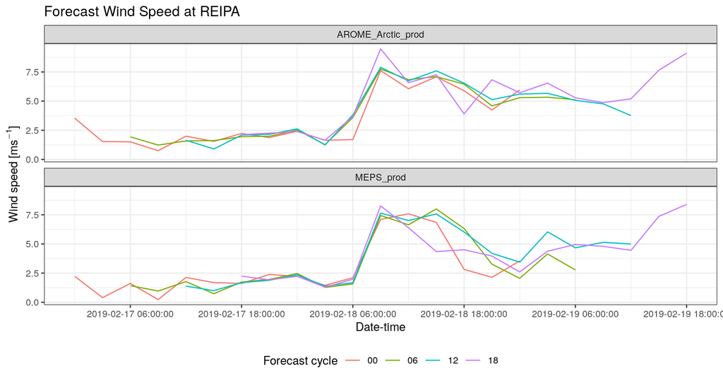

```r
reipa_sid <- filter(station_list, name == "REIPA") %>%
  pull(SID)
bind_fcst(s10m) %>%
  filter(SID == reipa_sid) %>%
  mutate(validdate = unix2datetime(validdate)) %>%
  ggplot(aes(validdate, forecast, colour = fcst_cycle)) +
    geom_line() +
    facet_wrap(vars(mname), ncol = 1) +
    scale_x_datetime(
      breaks = lubridate::ymd_hm(seq_dates(2019021706, 2019021918, "12h"))
    ) +
    labs(
      x      = "Date-time",
      y      = bquote("Wind speed [ms"^-1*"]"),
      colour = "Forecast cycle",
      title  = "Forecast Wind Speed at REIPA"
    ) +
    theme_bw() +
    theme(legend.position = "bottom")
```

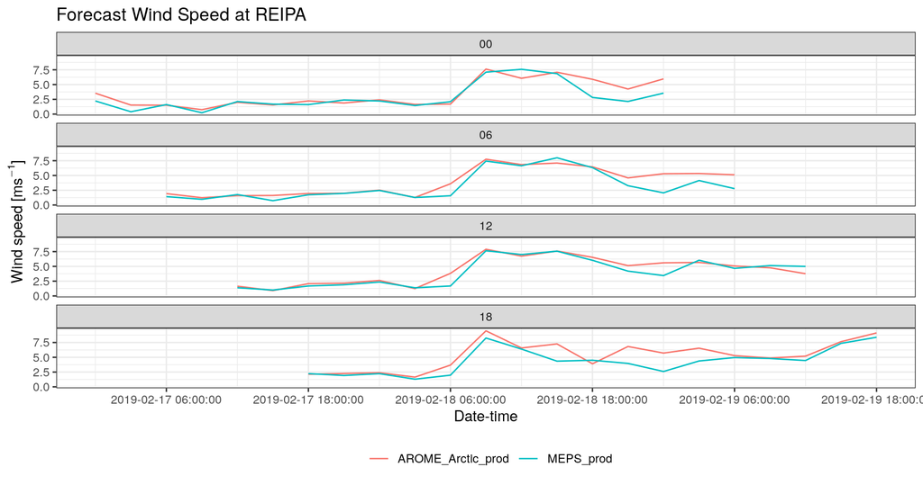

```r
bind_fcst(s10m) %>%
  filter(SID == reipa_sid) %>%
  mutate(validdate = unix2datetime(validdate)) %>%
  ggplot(aes(validdate, forecast, colour = mname)) +
    geom_line() +
    facet_wrap(vars(fcst_cycle), ncol = 1) +
    scale_x_datetime(
      breaks = lubridate::ymd_hm(seq_dates(2019021706, 2019021918, "12h"))
    ) +
    labs(
      x      = "Date-time",
      y      = bquote("Wind speed [ms"^-1*"]"),
      colour = "",
      title  = "Forecast Wind Speed at REIPA"
    ) +
    theme_bw() +
    theme(legend.position = "bottom")
```

Now let’s read in some observations. To make sure we get the correct dates for the observations we can get the first and last validdates from the forecast. We could also extract the station IDs from the forecasts - which we can do with a little bit of “functional programming”.

```r
station_ids <- map(s10m, pull, SID) %>%
  reduce(union)
obs <- read_point_obs(
  start_date = first_validdate(s10m),
  end_date   = last_validdate(s10m),
  stations   = station_ids,
  parameter  = "S10m",
  obs_path   = here("data/OBSTABLE")
)
```

Now that we have the observations we can join them to our forecast data using the function `join_to_fcst`. This will take each of the data frames in our forecast list and perform an inner join with the observations - that means that only rows that are common to both data frames are kept.

```r
s10m <- join_to_fcst(s10m, obs)
```

We have now added an observations column to each of the forecasts, so we could also include the observations in our plots.

Your turn:

- Add observations as a geom_point to your plots. [hint: you can map an aesthetic to an individual geom]

Solution:

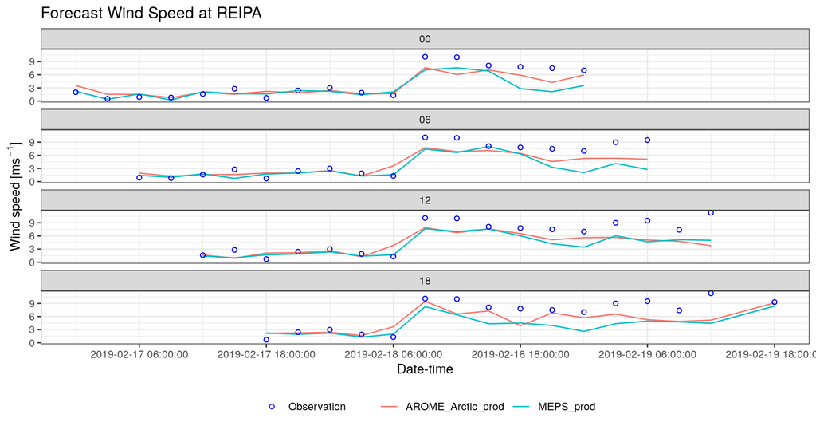

```r
bind_fcst(s10m) %>%
  filter(SID == reipa_sid) %>%
  mutate(validdate = unix2datetime(validdate)) %>%
  ggplot(aes(validdate, forecast, colour = mname)) +
    geom_line() +
    geom_point(aes(y = S10m, shape = "Observation"), colour = "blue") +
    scale_shape_manual(values = 21) +
    facet_wrap(vars(fcst_cycle), ncol = 1) +
    scale_x_datetime(
      breaks = lubridate::ymd_hm(seq_dates(2019021706, 2019021918, "12h"))
    ) +
    labs(
      x      = "Date-time",
      y      = bquote("Wind speed [ms"^-1*"]"),
      colour = "",
      title  = "Forecast Wind Speed at REIPA",
      shape  = ""
    ) +
    theme_bw() +
    theme(legend.position = "bottom")
```

#### Verifying deterministic forecasts

Now that we have both forecasts and observations we can verify the forecasts. This is very simple in harp - we just run the function `det_verify` giving that data and telling it which column has the observations:

```r
det_verify(s10m, S10m)
```

```
## $det_summary_scores
## # A tibble: 34 x 7
##    mname             leadtime num_cases   bias  rmse   mae  stde
##    <chr>                <int>     <int>  <dbl> <dbl> <dbl> <dbl>
##  1 AROME_Arctic_prod        0       629 0.137   2.57  1.80  2.57
##  2 AROME_Arctic_prod        3       679 0.0580  2.34  1.60  2.34
##  3 AROME_Arctic_prod        6       622 0.0390  2.38  1.65  2.38
##  4 AROME_Arctic_prod        9       679 0.0942  2.08  1.42  2.08
##  5 AROME_Arctic_prod       12       628 0.169   2.24  1.53  2.24
##  6 AROME_Arctic_prod       15       675 0.295   2.17  1.53  2.15
##  7 AROME_Arctic_prod       18       630 0.319   2.22  1.53  2.20
##  8 AROME_Arctic_prod       21       676 0.480   2.23  1.61  2.17
##  9 AROME_Arctic_prod       24       628 0.388   2.34  1.61  2.31
## 10 AROME_Arctic_prod       27       674 0.538   2.39  1.69  2.33
## # … with 24 more rows
##
## $det_threshold_scores
## data frame with 0 columns and 0 rows
##
## attr(,"parameter")
## [1] "S10m"
## attr(,"start_date")
## [1] "2019021700"
## attr(,"end_date")
## [1] "2019021718"
## attr(,"num_stations")
## [1] 828
```

You will see that the output is a list of two data frames - one fore summary scores and one for threshold scores. The threshold scores data frame contains only missing data as we didn’t give the function any thresholds to verify for. However, that is easily done:

```r
verif_s10m <- det_verify(s10m, S10m, thresholds = seq(2.5, 12.5, 2.5))
verif_s10m
```

```
## $det_summary_scores
## # A tibble: 34 x 7
##    mname             leadtime num_cases   bias  rmse   mae  stde
##    <chr>                <int>     <int>  <dbl> <dbl> <dbl> <dbl>
##  1 AROME_Arctic_prod        0       629 0.137   2.57  1.80  2.57
##  2 AROME_Arctic_prod        3       679 0.0580  2.34  1.60  2.34
##  3 AROME_Arctic_prod        6       622 0.0390  2.38  1.65  2.38
##  4 AROME_Arctic_prod        9       679 0.0942  2.08  1.42  2.08
##  5 AROME_Arctic_prod       12       628 0.169   2.24  1.53  2.24
##  6 AROME_Arctic_prod       15       675 0.295   2.17  1.53  2.15
##  7 AROME_Arctic_prod       18       630 0.319   2.22  1.53  2.20
##  8 AROME_Arctic_prod       21       676 0.480   2.23  1.61  2.17
##  9 AROME_Arctic_prod       24       628 0.388   2.34  1.61  2.31
## 10 AROME_Arctic_prod       27       674 0.538   2.39  1.69  2.33
## # … with 24 more rows
##
## $det_threshold_scores
## # A tibble: 170 x 40
##    mname leadtime threshold num_cases_for_t… num_cases_for_t… num_cases_for_t…
##    <chr>    <int>     <dbl>            <dbl>            <dbl>            <dbl>
##  1 AROM…        0       2.5              461              418              421
##  2 AROM…        3       2.5              482              418              436
##  3 AROM…        6       2.5              410              348              358
##  4 AROM…        9       2.5              449              365              403
##  5 AROM…       12       2.5              410              328              363
##  6 AROM…       15       2.5              459              358              422
##  7 AROM…       18       2.5              437              338              389
##  8 AROM…       21       2.5              497              374              466
##  9 AROM…       24       2.5              452              348              413
## 10 AROM…       27       2.5              496              374              471
## # … with 160 more rows, and 34 more variables: cont_tab <list>,
## #   threat_score <dbl>, hit_rate <dbl>, miss_rate <dbl>,
## #   false_alarm_rate <dbl>, false_alarm_ratio <dbl>, heidke_skill_score <dbl>,
## #   pierce_skill_score <dbl>, kuiper_skill_score <dbl>, percent_correct <dbl>,
## #   frequency_bias <dbl>, equitable_threat_score <dbl>, odds_ratio <dbl>,
## #   log_odds_ratio <dbl>, odds_ratio_skill_score <dbl>,
## #   extreme_dependency_score <dbl>, symmetric_eds <dbl>,
## #   extreme_dependency_index <dbl>, symmetric_edi <dbl>,
## #   threat_score_std_error <dbl>, hit_rate_std_error <dbl>,
## #   false_alarm_rate_std_error <dbl>, false_alarm_ratio_std_error <dbl>,
## #   heidke_skill_score_std_error <dbl>, pierce_skill_score_std_error <dbl>,
## #   percent_correct_std_error <dbl>, equitable_threat_score_std_error <dbl>,
## #   log_odds_ratio_std_error <dbl>, log_odds_ratio_degrees_of_freedom <dbl>,
## #   odds_ratio_skill_score_std_error <dbl>,
## #   extreme_dependency_score_std_error <dbl>, symmetric_eds_std_error <dbl>,
## #   extreme_dependency_index_std_error <dbl>, symmetric_edi_std_error <dbl>
##
## attr(,"parameter")
## [1] "S10m"
## attr(,"start_date")
## [1] "2019021700"
## attr(,"end_date")
## [1] "2019021718"
## attr(,"num_stations")
## [1] 828
```

As you can see, a very large number of scores are computed. harp has a function for plotting point verification scores, `plot_point_verif`. For summary scores, you just need to give it the verification data and tell it which score you’d like to plot, as well as tell the function that it is deterministic verification data.

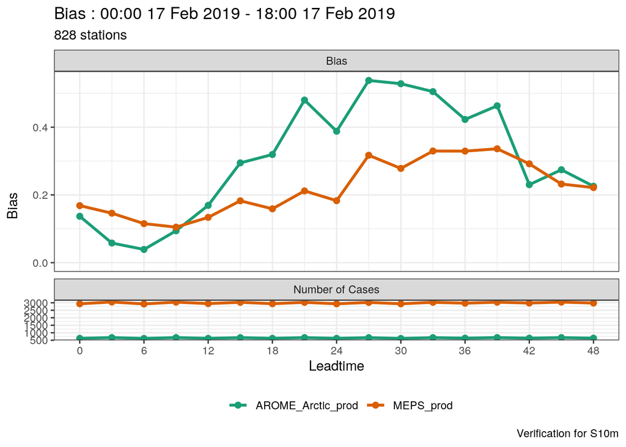

```r
plot_point_verif(verif_s10m, bias, verif_type = "det")
```

One thing you’ll immediately notice is that the number of cases for MEPS_prod is much larger than for AROME_Arctic_prod. This means that in this verification we are not making a fair comparison - we should actually only be verifying the dates and locations that are common to both systems. harp provides the function `common_cases()` to do just that!

```r
common_cases(s10m)
## ● AROME_Arctic_prod
## # A tibble: 10,170 x 14
##    fcdate fcst_cycle leadtime model_elevation     p parameter   SID units
##     <int> <chr>         <int>           <dbl> <dbl> <chr>     <int> <chr>
##  1 1.55e9 00                0            63.9    NA S10m       1001 m/s
##  2 1.55e9 00                0             3.3    NA S10m       1010 m/s
##  3 1.55e9 00                0             0.5    NA S10m       1015 m/s
##  4 1.55e9 00                0           169.     NA S10m       1018 m/s
##  5 1.55e9 00                0            73.5    NA S10m       1023 m/s
##  6 1.55e9 00                0            22.2    NA S10m       1025 m/s
##  7 1.55e9 00                0            14.4    NA S10m       1026 m/s
##  8 1.55e9 00                0            -2.6    NA S10m       1033 m/s
##  9 1.55e9 00                0           125.     NA S10m       1036 m/s
## 10 1.55e9 00                0           160.     NA S10m       1037 m/s
## # … with 10,160 more rows, and 6 more variables: validdate <int>,
## #   AROME_Arctic_prod_det <dbl>, lon <dbl>, lat <dbl>, elev <dbl>, S10m <dbl>
##
## ● MEPS_prod
## # A tibble: 10,170 x 14
##    fcdate fcst_cycle leadtime model_elevation     p parameter   SID units
##     <int> <chr>         <int>           <dbl> <dbl> <chr>     <int> <chr>
##  1 1.55e9 00                0            36.4    NA S10m       1001 m/s
##  2 1.55e9 00                0             4.1    NA S10m       1010 m/s
##  3 1.55e9 00                0             2.6    NA S10m       1015 m/s
##  4 1.55e9 00                0           152.     NA S10m       1018 m/s
##  5 1.55e9 00                0            69.1    NA S10m       1023 m/s
##  6 1.55e9 00                0             8.1    NA S10m       1025 m/s
##  7 1.55e9 00                0             5.2    NA S10m       1026 m/s
##  8 1.55e9 00                0            28.5    NA S10m       1033 m/s
##  9 1.55e9 00                0           129      NA S10m       1036 m/s
## 10 1.55e9 00                0            94.5    NA S10m       1037 m/s
## # … with 10,160 more rows, and 6 more variables: validdate <int>,
## #   MEPS_prod_det <dbl>, lon <dbl>, lat <dbl>, elev <dbl>, S10m <dbl>
s10m <- common_cases(s10m)
```

You will see that now both AROME_Arctic_prod and MEPS_prod have the exact same number of rows in their data. Now if we run the verfication again and plot the same score we will see that both forecasting systems have the same number of cases.

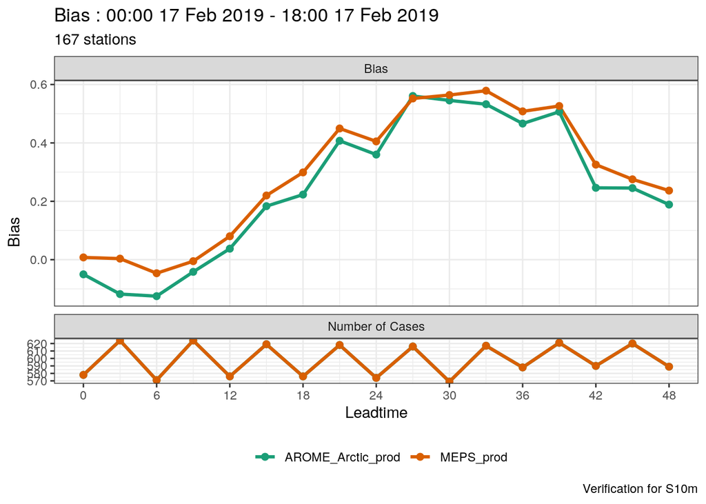

```r
verif_s10m <- det_verify(s10m, S10m, thresholds = seq(2.5, 12.5, 2.5))
plot_point_verif(verif_s10m, bias, verif_type = "det")
```

Your turn:

- Try plotting one of the threshold scores (frequency_bias, for example). Try to figure out wht the plot looks so weird

Solution:

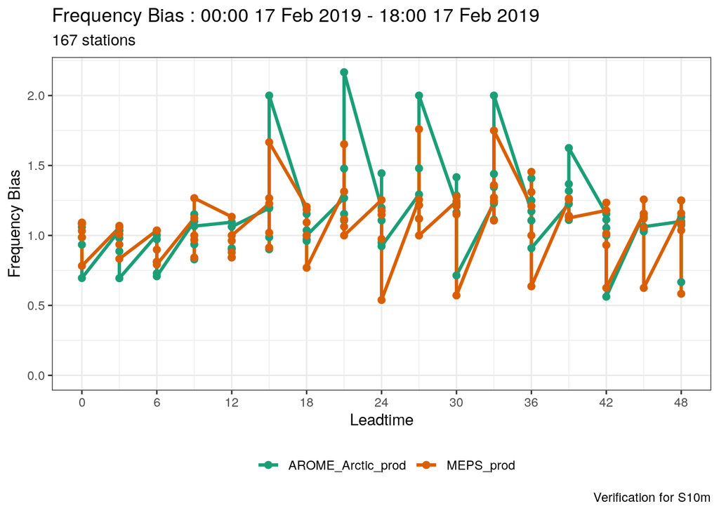

```r
plot_point_verif(verif_s10m, frequency_bias, verif_type = "det")
```

The plot looks weird becasue it’s attempting to plot scores for all thresholds at the same time.

When we have more than one threshold, we need to tell `plot_point_verif` what to do - there are 2 options - to facet or to filter, with the arguments `facet_by` or `filter_by`. These arguments work in pretty much the same way as `facet_wrap`. For example if we wanted the facet the scores by threshold, we would do

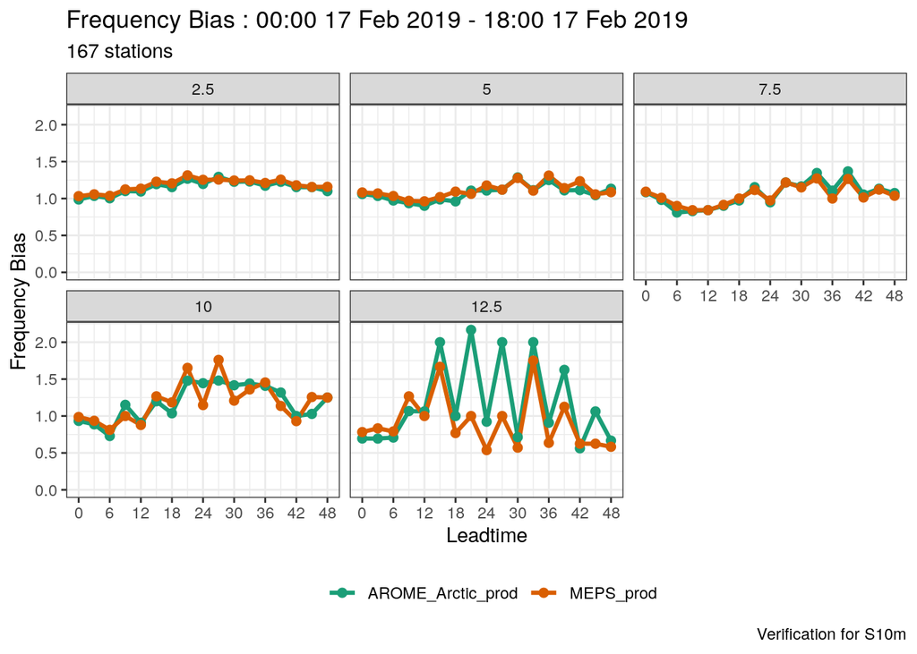

```r
plot_point_verif(
  verif_s10m,
  frequency_bias,
  verif_type = "det",
  facet_by   = vars(threshold)
)
```

Or, if we just wanted the plot for a threshold of 7.5 ms<sup>-1</sup>, we would use `filter_by`

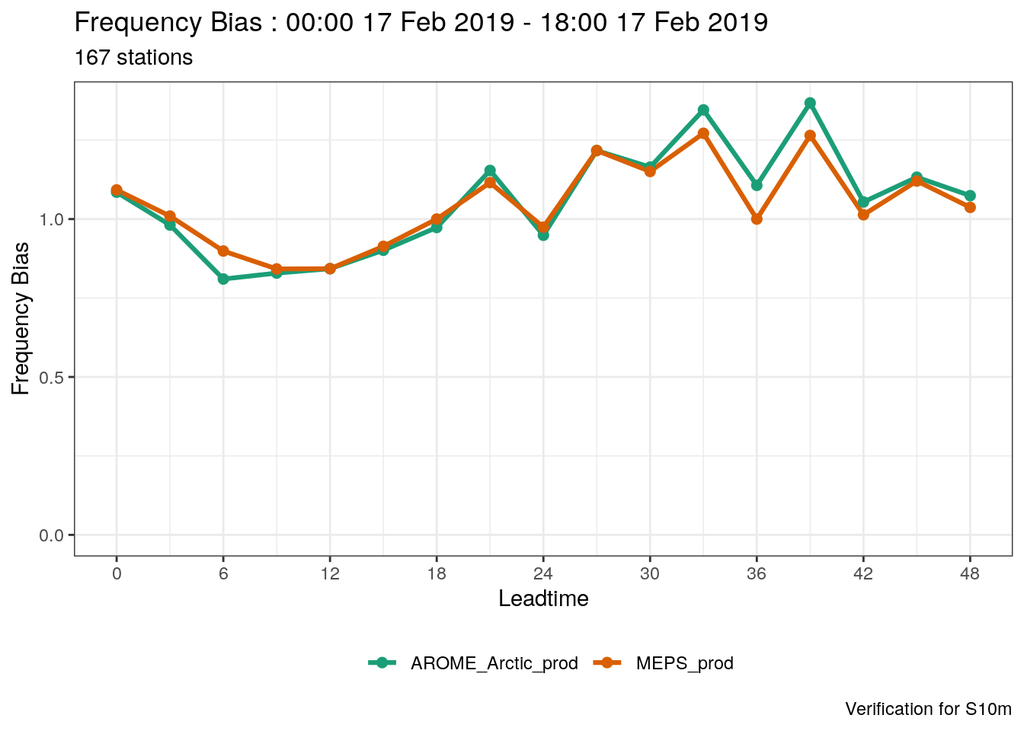

```r
plot_point_verif(
  verif_s10m,
  frequency_bias,
  verif_type = "det",
  filter_by  = vars(threshold == 7.5)
)
```